# R-Ladies NYC Package Workshop

## R-Ladies NYC Package Workshop

[figure not shown]

## We will cover:

- Using RStudio to set up your package
- Package structure
- Dependencies
- Creating functions
- Documenting functions
- Vignettes
- Sharing the package with others
- Hex stickers

## Why Make a Package?

- You have used the same function that you wrote multiple times
- Your workplace uses the same functions, graph themes, datasets, database connections, etc and you want to easily share them
- You want to share your timesaving work with the world

## Packages used for making packages

- roxygen: document your package
- devtools: use various tools for R development

## Creating your package

You can create a package in two ways:

1. From RStudio, go to the menu bar, go to *File*, *New Project*, *Choose New Directory*, and then select *R Package*, after giving the project a name click *Create Project*
2. Using devtools, you can run the following code in R:

```r
devtools::create("path/to/package/packagename")
```

## Once generated either way, your package will have:

- an R/ directory
- a DESCRIPTION file
- a NAMESPACE file
- an RStudio project file *packagename.Rproj*

## Package structure

[figure not shown]

## R /directory

- Contains an R file where we will put our functions
- By default it is named *Hello.R* but you can rename to anything you want

## Example - a function that generates a simulated dataset

```r
generate_cars <- function(n_cars = 100,
                          dep = 0.50,
                          new = 15000) {
  data.frame(mileage_per_year = rpois(n_cars, lambda = 50000)) %>%
    dplyr::mutate(price = new - dep * mileage_per_year)
                          }
```

## Writing functions

Recommendations:

- Always include functions you are using from other packages as *pkg::fun()*, this will help you avoid any function name conflicts in the future
- List the package in DESCRIPTION so that it’s installed (will cover later)
- When using the pipe I avoid this rule and add *importFrom(dplyr, “%>%”)* to NAMESPACE (will cover later)

## DESCRIPTION file

[figure not shown]

## DESCRIPTION: Dependencies

*Imports*:

- Packages listed here must be present for your package to work, they will be installed if they were not already
- However, it will not attach them, meaning it does not run *library(pkg_needed)*
- The best practice is to explicitly refer to external functions using the syntax *pkg_needed::function()*
- You can also add them using *usethis::use_packages()*

*Suggest*:

- Unlike *Imports* these will not be installed
- Put packages here that are almost never used in your package, eg only one function uses it, only shows up in examples, etc

## DESCRIPTION: Versioning

- If you need a specific version of a package:

```r
Imports:
    ggvis (>= 0.2),
    dplyr (>= 0.3.0.1)
```

- In RStudio you can look under the *Packages* tab and under *Version*

## NAMESPACE: export

Important if you want to publish your package on CRAN/share your package:

- For a function to be usable when loaded, you must export it
- Add *#’ @export* before defining your function and after your documentation

```r
#' @export
foo <- function(x, y, z) {
  ...
}
```

- Run *devtools::document()*
- Check NAMESPACE file and run tests to check that the specification is correct
- NB: You might want to keep some functions private/unexposed to the user, in order to do that do not add *#’ @export* before defining your function

## NAMESPACE: import

This is important regardless of whether you want to publish on CRAN or not:

- NAMESPACE controls which external functions can be used by your package without having to use *::*
- Very important if you want to use the pipe (add *importFrom(dplyr, “%>%”)*)
- It’s common for packages to be listed in Imports in DESCRIPTION, but not in NAMESPACE

## NAMESPACE: import

General recommendations:

- List the package in DESCRIPTION so that it’s installed, then always refer to it explicitly with *pkg::fun()* (best option, most tedious)
- If you are using only a few functions then always do this
- If you are using functions repeatedly you can use *importFrom(pkg, fun)*
- You can import all of the functions of the package with *importFrom(pkg)* (worst option, less tedious)

## Documenting your function

Use the roxygen2 package

Hadley’s steps:

1. Add roxygen comments to your .R files
2. Run devtools::document() to convert roxygen comments to .Rd files
3. Preview documentation with *?your_function_name*
4. Rinse and repeat until the documentation looks the way you want

## Documentation Example

```r
#' Generates simulated car dataset
#'
#' This function generates a dataset that simlulates
#' random mileage per year using parameters for the number
#' of cars, the depreciation rate, and the average price
#' of a new car.
#' @param n_cars number of cars
#' @param dep depreciation rate
#' @param new average value of a car when new
#' @return a dataset
#' @examples
#' generate_cars(n_cars = 100, dep = 0.50, new = 15000)
```

## Vignettes

To create your vignette:

- *devtools::use_vignette(“my-vignette”)*

This will :

- Create a *vignettes/* directory
- Add the necessary dependencies to *DESCRIPTION*
- Draft a vignette, *vignettes/my-vignette.Rmd*

Then you can:

- Modify your vignette
- Click *Knit* on Rstudio

## Installing Your Package

- devtools::install()
- in RStudio, under the Build Tab click the Install and Restart button

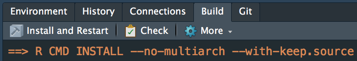

- or in the command line, you can write R CMD INSTALL packagename

## Sharing Your Package

- If your package is on github, other people can install your package by running *install_github(“username/packagename”)*
- If it is on bitbucket, you can do the same thing but with *install_bitbucket*
- You can run *devtools::build()* and this will generate a *packagename_0.1.0.tar.gz* file of your package
- You can share this compressed file with others but to install it they have to go put this file in the directory where their R packages live and then run *R CMD INSTALL packagename_0.1.0.tar.gz*

## Hex Stickers using hexSticker

- Needs ImageMagik, so go to terminal and brew install ImageMagick or sudo port install ImageMagick

```r
library(hexSticker)
imgurl <- here::here("images/vroom.png") # give path of image
hexSticker::sticker(imgurl,              # image path
        package = "vroomr",              # package name on sticker
        p_size = 8,                      # size of package name text
        p_color = "#BD1816",             # color of package name text
        s_x = 1,                         # x position for plot/image
        s_y = 0.75,                      # y position for plot/image
        s_width = 0.6,                   # width of plot/image
        h_fill = "#ffffff",              # hexagon fill color
        h_color = "#BD1816",             # hexagon border color
        filename =                       # output location
          here::here("images/vroomr_hex.png"))
```

## Hex Sticker Example

[figure not shown]

## Summary of Adding Functions

- Open your package_functions.R file and add your new function
- Add the fancy comments with *#’* in order to describe the function, give an example of it, and export it (make sure *#’ @export* is at the end of your comments right before the function)
- Now, run *devtools::document()*
- Check that the documentation was generated properly (it should be under the *man* folder or you can run *?function_name*)
- Check that you can see *export(function_name)* in the NAMESPACE file
- On the *Build* tab, click *Install and Restart* and make sure it ran without any errors, you should see library(package_name) in the console

## THANK YOU

- Erin Grand, @astroeringrand
- Emily Zabor, @zabormetrics
- Ludmila Janda, @ludmila_janda
- RLadiesNYC
- Vroomates: JF Blanchette-Guertin, Deni Stott, Laura Seiferth, Andrew McDonald, John Watson, Diego Ramallo, Pedro, Scott McBride, Eric Hepp, Molly Thrachtman, Brittney Hancock